# Introduction to Supersonic Routing

David Marsh

2026-01-16

## Introduction

This vignette provides an end-to-end example of using the `himach` package to find the quickest route for a supersonic (“high Mach”) aircraft that is allowed to fly supersonic over sea, but only subsonic over land.

```r
#the libraries needed for the vignette are
library(himach)
library(dplyr, quietly = TRUE, warn.conflicts = FALSE)
library(ggplot2)
library(sf)
library(s2)
library(rnaturalearthdata)
```

## Aircraft

You need a dataframe that defines one or more aircraft. This needs, at minimum, to have the following fields:

- `id` and `type`: a very short, and longer text identifier for this aircraft
- `over_sea_M` and `over_land_M`: two speeds, given as a Mach number
- `accel_Mpm`: acceleration in Mach per minute between these two
- `arrdep_kph`: the speed on arrival and departure from airport, given in km per hour
- `range_km`: range in km

Other fields are optional, but it is recommended to include `notes` to give more information.

To convert between kph and Mach at the sort of cruise altitudes that supersonic aircraft use, we use a fixed value `mach_kph`=1062.

The cruise speeds over sea and over land are clearly intended to be supersonic and subsonic, respectively. But this is not required. You might want both subsonic, to include a comparator, subsonic aircraft. Or you might want to have both supersonic, to explore routes when so-called “mach cut-off” conditions prevail. `himach` doesn’t require either speed to be within a particular range of values.

Run this minimum dataset through `make_aircraft` to get the additional fields that are needed. Alternatively, if you run `make_aircraft` with no parameters, it creates a set of test aircraft. This test set is based on public data for 3 aircraft (though the `accel_Mpm`, `arrdep_kph` are educated guesses), and fantasy for the 4th one, which has been designed for testing purposes and might not be pleasant to fly in.

`make_aircraft` adds some fields, converting Mach to kph, and calculating the time to transition between the two speeds. This ‘transition penalty’ `trans_h` in hours, is used in the routing search as a time penalty whenever a transition from subsonic to supersonic (or vice versa) is needed; typically this is when switching from flying over land to flying over sea (or vice versa).

```r
# example for your own data - see above for column headings
# aircraft <- read.csv("data/aircraft.csv", stringAsFactors = FALSE)
# aircraft <- make_aircraft(aircraft)
# strongly recommended to record the source file name for later reference
# this works even better if your source file has a date embedded in the name
# attr(aircraft, "aircraftSet") <- "aircraft.csv"

# example if you have no data of your own - know that this will use default, so turn off warning
aircraft <- make_aircraft(warn = FALSE)
```

## Airports

Similarly, we need a dataset describing airports. This needs, at minimum, to have the following fields:

- `APICAO`: the 4-character ICAO code for the airport
- `long` and `lat`: the longitude and latitude, in decimal degrees (E and N being positive)

Other fields are optional, but you might find it useful to include a longer airport name `ap_name` to give more information, as well as other fields containing geographical details, such as country.

As with the aircraft, you can load your own data set and then run it through `make_airports` to add a geo-coded field to it. If you don’t have a list, then `make_airports` will use the dataset from `airportr` package.

For this vignette, we use a very restricted set: just New Zealand. We geocode the airports using a built-in coordinate reference system (CRS) `crs_Pacific`; the maps will have the same.

```r
# example for your own data
# airports <- read.csv("data/airports.csv", stringAsFactors = FALSE)
# airports <- make_airports(airports)

# example if you have no data of your own
airports <- make_airports(crs = crs_Pacific) %>%
  filter(substr(APICAO, 1, 1)=="N") #just New Zealand, and neighbours
```

```
#> Using default airport data: airportr::airport.
```

In fact you need two airport sets, because you need to say where flights can stop to refuel. If an aircraft cannot make a journey in a single leg, due to lack of range, `himach` automatically searches for the best refuelling option. This can easily multiply the number of searches by 5 or 10, so choose a limited number of likely ‘good’ options: islands, coastal points, or on narrow segments of land where the aircraft would have to slow down anyway. In our theoretical example, we have a test aircraft with an artificially-reduced range, and we make just one refuel point available: coastal and central at the same time, Wellington.

The refuelling dataset needs to be the same format as the full airports set. So easiest is to filter the airports set, or do an inner join if your refuelling list is a dataset read in from a file.

```r
refuel_ap <- airports %>%
  filter(APICAO=="NZWN")
```

For the vignette, we’ll assume that Wellington has a long enough runway. In fact `himach` does not currently check whether a runway is long enough for the aircraft selected.

## Maps

Next you need a set of shapefiles covering your area of interest (usually worldwide). These need only to distinguish land and sea, but starting off at country level can be useful, for example to filter out the Antarctic, which is not likely to see traffic. You can save time by ignoring airspace South of 60S, for example.

Finer resolution is better, because small islands can become larger obstacles. After a no-fly coastal buffer, say around 30km wide, is applied, even a 1km wide island is an obstacle 61km wide. There are some useful starter maps in `rnaturalearth` (use the `countries` versions), but you need to decide what is good enough for your purposes. Two tests:

- If you have a 30km buffer do you have aircraft passing between Crete and mainland Greece without slowing down? Then you’re missing the island of Antikythera, famous for its ancient, analogue computer.
- With a 50km buffer, do you have routes passing supersonically between Taiwan and the Philippines? Then you are missing either Y’Ami or Xiao-lan Yu, which are just 98km apart.

Licensing and your intended use may influence which maps are available to you. We have used data from Eurostat in the past (at 1:1M scale, [Eurostat country shape files](https://ec.europa.eu/eurostat/web/gisco/geodata/administrative-units/countries)). For the purpose of rapid testing and this vignette, we use a map which is provided by [Stats NZ](https://datafinder.stats.govt.nz) (as at January 2020) and licensed by Stats NZ for re-use under the Creative Commons Attribution 4.0 International licence.

In fact, we need two files: one is the basic outline of the land, largely used for visualisation; the second is derived from this, and adds a 30km buffer around the coastline to indicate the area where supersonic flight is not allowed. A different buffer is of course possible, 30km is about right for the expected radius of the footprint of the supersonic boom, but your expertise will determine what is needed.

Since the shape file is large, we provide a simplified outline `NZ_coast` and also the buffer `NZ_buffer30` within `himach`. These are in the original projection used by Stats NZ. For global work, it’s strongly recommended to use one of the following:

- `crs_Atlantic`: “Robinson”, a mid 20C classic view, with Atlantic centre
- `crs_Pacific`: A Pacific-centred variant on this with `crs=sf::st_CRS("+proj=robin +lon_0=180 +x_0=0 +y_0=0 +ellps=WGS84 +datum=WGS84 +units=m +no_defs")`.

We leave this transformation step in the process to emphasise the need to think about which projection to use.

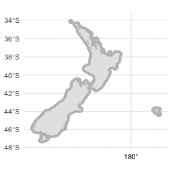

```r
# if you are using your own shp file
# NZ_shp <- sf::read_sf("...../territorial-authority-2020-clipped-generalised.shp")
# NZ_coast <- NZ_shp %>% sf::st_simplify(dTolerance = 1000) %>% sf::st_union()
# NZ_buffer30 <- NZ_coast %>% sf::st_buffer(30 * 1000) %>% sf::st_union()

# get test datasets
NZ_coast <- hm_get_test("coast")
NZ_buffer30 <- hm_get_test("buffer")

# The in-built test maps are already in crs_Pacific
# All that remains is to illustrate the land and buffer
ggplot(NZ_buffer30) +
    geom_sf(colour = NA, fill = "grey75")  +
      geom_sf(data = NZ_coast, fill = "grey90", colour = NA)+
    theme_minimal()
```

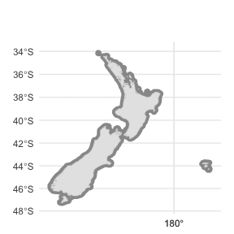

```r
# a quicker way to do all of this is to use map_routes, with no routes
# by default map_routes simplifies maps to a coarse 10km step
# for this small example we want something finer-grained
map_routes(NZ_coast, fat_map = NZ_buffer30, crs = crs_Pacific,
           simplify_km = 2)
```

On the scale of this example, the resolution of the map is good. If you are doing global analysis, then you will need two things: a detailed map on which to base the coastal buffer (eg `rnaturalearthhires::countries10`); and then a simplified version, because otherwise plotting results will take a long time.

The version in comments in the chunk above uses the basic `sf` functionality to simplify and buffer. For reasons that we go into in another vignette, it’s probably better to use `s2` for adding a buffer. That gives something like the following code (none of which is used further in this vignette).

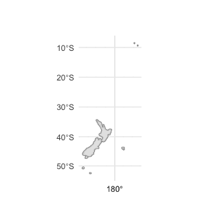

```r
# you really want to use rnaturalearthhires::countries10
# but that's heavy for this vignette
map_NZ <- rnaturalearthdata::countries50 %>%
   st_as_sf() %>%
   filter(name == "New Zealand")
# use attributes to track where this came from
attr(map_NZ, "source") <- "rnaturalearthdata::countries50"
attr(map_NZ, "Antarctic") <- FALSE
attr(map_NZ, "simplify_m") <- NA

# using s2 for buffering
NZ_plus30 <- map_NZ %>%
   st_as_s2() %>%
   s2::s2_buffer_cells(distance = 30000, max_cells = 1000) %>%
   st_as_sfc()
# again, use attributes to record the metadata
attr(NZ_plus30,"buffer_m") <- 30000
attr(NZ_plus30,"max_cells") <- 1000

# and then simplify for plotting
# just give 1 example here
map_NZ_2k <- map_NZ %>%
   st_as_s2() %>%
   s2::s2_simplify(tolerance = 2000) %>%
   st_as_sfc()
attr(map_NZ_2k, "simplify_m") <- 2000

# example map, himach::map_routes but without any routes
# by default map_routes simplifies maps to a coarse 10km step
# for this small example we want something finer-grained
map_routes(map_NZ_2k, fat_map = NZ_plus30, crs = crs_Pacific,
           simplify_km = 2)
```

## Create a grid

The route is constructed on a grid that covers the entire map. You could think of this grid as being a regular network of waypoints and route segments at some high, cruise flight level, though `himach` doesn’t assign a flight level to it. The links in this grid have nominal length: 30-40km appears sufficient, though we will use a coarser grid for this test. By ‘nominal’ we mean that the grid is constructed not on a strict distance basis, but between points along particular lines of latitude, so the links vary in length.

To this are added connections to airports. These connections have a nominal or target length, say 150km, to represent the distance covered when accelerating to cruise speed, or decelerating back when landing. In practice, the length varies, because it depends on the (horizontal) distance from airport to grid.

Normally the grid is too large to plot helpfully, but in this very limited set, it can be visualised.

```r
target_km <- 150
system.time(
p_grid <- make_route_grid(NZ_buffer30, "NZ lat-long at 150km",
                             target_km = target_km, classify = TRUE,
                         lat_min = -49, lat_max = -32,
                         long_min = 162, long_max = 182)
)
```

```
#>
#>    user  system elapsed
#>   0.285   0.012   0.314
```

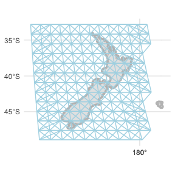

```r
# whether this map is useful depends on the target_km v the overall size of the map
ggplot(NZ_buffer30) +
    geom_sf(colour = NA, fill = "grey75")  +
      geom_sf(data = NZ_coast, fill = "grey90", colour = NA) +
  geom_sf(data = p_grid@lattice,
          aes(geometry=geometry), colour="lightblue", size = 0.2) +

    theme_minimal()
```

## Routes!

Finally we’re ready to do some routing of aircraft.

The result is a little coarse, because we have used a coarse grid. `himach` simplifies sections of route to great circles where it can, but all points where two great-circle segments join will be vertices of this grid. You can experiment by using the built-in `NZ_grid` instead. That has a 30km resolution, but is built on the same `NZ_buffer` map, so nothing else needs to change.

You can control the amount of reporting during the creation of routes with the `himach.verbosity` option, cumulatively you get: 0) nothing, 1) route & legs, 2) major stages (envelope, phases, shortcuts) 3) use of cache, route stages & some timings.

```r
options("himach.verbosity" = 4) #for some output
# from Auckland to Christchurch
ap2 <- make_AP2("NZAA","NZCH",airports)

# normally you do NOT want to do this, but for the vignette we
# work with an empty cache
hm_clean_cache()

routes <- find_route(aircraft[4,],
                     ap2,
                     fat_map = NZ_buffer30,
                     route_grid = p_grid,
                     ap_loc = airports)
```

```
#> Route:-NZAA<>NZCH----
#>   Not cached: calculating...
#> Leg: NZAA<>NZCH Aircraft: Test-only SST
#>   Starting envelope: 0
#>  Cut envelope from lattice: 0.1
#>   TOC/TOD not cached: calculating...
#>   TOC/TOD not cached: calculating...
#>   Got costed lattice: 0.1
#>   Got path: 0.1
#>  Calculated phase changes
#>   Ready to recurse
#>   transition 1.  2
#>   sea 2.  2
#>   transition 3.  4
#>  Done recursion
#>  Checking Shortcuts
```

In fact, normally you’ll want to run a selection of routes in one batch. While `find_route` takes only one aircraft and one airport-pair, there is a wrapper which takes a list of aircraft ids (as in the first column in the aircraft data), and a 2-column matrix or dataframe of 4-letter ICAO codes. It creates all combinations of these, and runs `find_route` for each. This wrapper function is called `find_routes`.

There is a progress bar, though this interacts with the progress messaging and the remaining time estimate tends to be too high because calculation speeds up as the cache fills up.

```r
options("himach.verbosity" = 2) # anything more than 1 is messy, because of the progress bar
ap2 <- matrix(c("NZAA","NZCH","NZAA","NZDN","NZGS","NZCH"),
              ncol = 2, byrow = TRUE)
ac <- aircraft[c(1,4), ]$id

routes <- find_routes(ac, ap2, aircraft, airports,
                      fat_map = NZ_buffer30,
                     route_grid = p_grid,
                     refuel = refuel_ap)
```

```
#> Route:-NZAA<>NZCH----
#> Leg: NZAA<>NZCH Aircraft: SST M2.2
#>  Cut envelope from lattice: 0
#>  Calculated phase changes
#>  Done recursion
#>  Checking Shortcuts
#>
#> Route:-NZAA<>NZDN----
#> Leg: NZAA<>NZDN Aircraft: SST M2.2
#>  Cut envelope from lattice: 0
#>  Calculated phase changes
#>  Done recursion
#>  Checking Shortcuts
#>
#> Route:-NZCH<>NZGS----
#> Leg: NZCH<>NZGS Aircraft: SST M2.2
#>  Cut envelope from lattice: 0
#>  Calculated phase changes
#>  Done recursion
#>  Checking Shortcuts
#>
#> Route:-NZAA<>NZCH----
#>
#> Route:-NZAA<>NZDN----
#>  Too far for one leg.
#> Leg: NZAA<>NZWN Aircraft: Test-only SST
#>  Cut envelope from lattice: 0
#>  Calculated phase changes
#>  Done recursion
#>  Checking Shortcuts
#> Leg: NZDN<>NZWN Aircraft: Test-only SST
#>  Cut envelope from lattice: 0
#>  Calculated phase changes
#>  Done recursion
#>  Checking Shortcuts
#>
#> Route:-NZCH<>NZGS----
#> Leg: NZCH<>NZGS Aircraft: Test-only SST
#>  Cut envelope from lattice: 0
#>  Calculated phase changes
#>  Done recursion
#>  Checking Shortcuts
#>
```

Once you have some routes, you will probably want (a) a summary of the routes created (b) a map. There are functions for both of these.

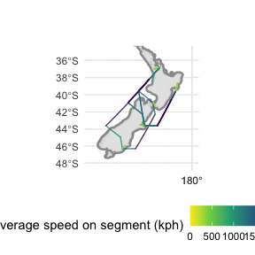

```r
# create route summary
rtes <- summarise_routes(routes, airports)

# draw a basic map
map_routes(NZ_coast, routes, crs = crs_Pacific, fat_map =  NZ_buffer30, simplify_km = 2)
```

Maps are created with `ggplot2` so the last map generated can be saved with `ggsave` in the usual way.